# Assignment 2

enzoalf@stanford.edu

10/8/2020

## Introduction

The global objective of this assignment is to analyze the education outcomes in one county in the Bay Area. I personally chose to analyze the education outcomes in the San Francisco county. To do that I will:

1. Plot a bar chart showing the San Francisco county educational attainment by race (proportion of each race in every category of educational attainment), then compare it with a bar chart showing the global Bay Area educational attainment by race
2. Display a map showing an estimate of the number and percentage of K-12 students who have no internet access at home in the San Francisco county and the same map for the whole Bay Area, and discuss on potential patterns
3. Analyze the migration in the San Francisco county using a flow table and comment on the potential sources of educational mobility

You may show or hide the code chunks by clicking on the *Code* buttons on the right of the document.

## Educational attainment by race

For my educational outcomes in the San Francisco county analysis, I will first comment on the relations between race and educational attainment in the county and compare it with the situation in the Bay Area.

### In San Francisco county

First, let’s extract the data from the American Community Survey (ACS) Census Bureau. I will use the data from 2018 and the 5 years before stocked using the ID `C15002` . As I am only interested in the San Francisco county, I will only extract data from `region = "county:075", regionin = "state:06"`.

```r
Sys.setenv(CENSUS_KEY="c8aa67e4086b4b5ce3a8717f59faa9a28f611dab")

acs_vars_2018_5yr <-
  listCensusMetadata(
    name = "2018/acs/acs5",
    type = "variables"
  )

census_race_labels <-
  c(
    "White Alone",
    "Black or African American",
    "American Indian and Alaska Native Alone",
    "Asian Alone",
    "Native Hawaiian and Other Pacific Islander Alone",
    "Some Other Race Alone",
    "Two or More Races"
  )

sf_educ_race <-
  1:7 %>%
  map_dfr(function(x){
    getCensus(
      name = "acs/acs5",
      vintage = 2018,
      region = "county:075",
      regionin = "state:06",
      vars = paste0("group(C15002",LETTERS[x],")")
    ) %>%
      select(!c(GEO_ID,state,NAME) & !ends_with(c("EA","MA","M"))) %>%
      pivot_longer(
        ends_with("E"),
        names_to = "variable",
        values_to = "estimate"
      ) %>%
      left_join(
        acs_vars_2018_5yr %>%
          select(name, label),
        by = c("variable" = "name")
      ) %>%
      select(-variable) %>%
      separate(
        label,
        into = c(NA,NA,'SEX','EDUCATION'),
        sep = "!!"
      ) %>%
      filter(!is.na(EDUCATION)) %>%
      mutate(race = census_race_labels[x])%>%
      select(
        !c(county,SEX)
      )
  })
```

I can now plot the total number of each race in every category of educational attainment within the county as a bar chart. Because the x-axis labels are long character strings, I flip the axes using the `coord_flip()` function to better visualize the data:

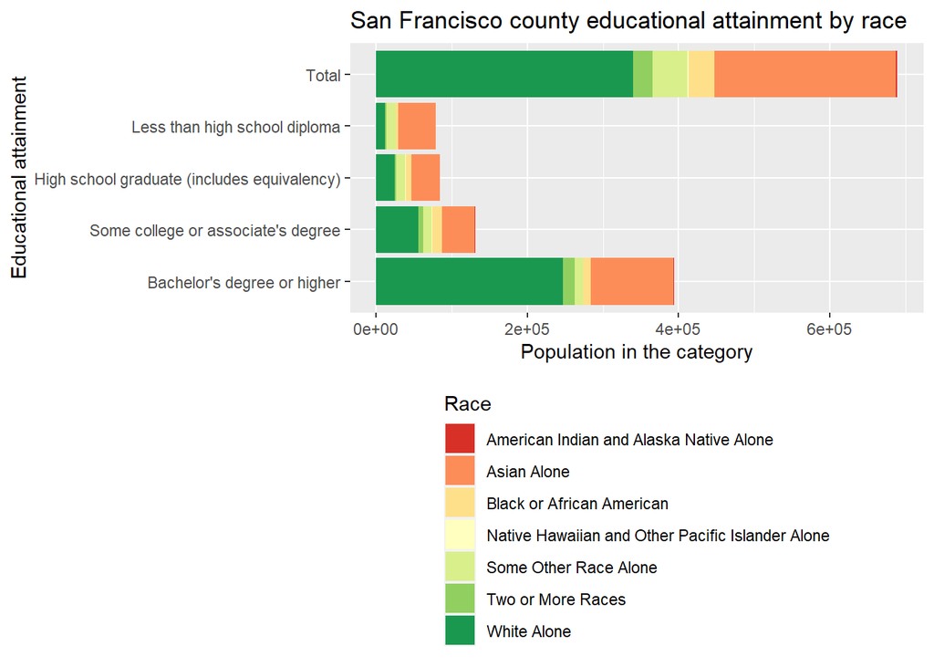

```r
sf_educ_total <-
  sf_educ_race %>%
  group_by(race) %>%
  summarize(estimate = sum(estimate)) %>%
  mutate(EDUCATION = "Total")

saveRDS(sf_educ_total,'sf_educ_total.rds')

sf_educ_race %>%
  group_by(EDUCATION, race) %>%
  summarize(estimate = sum(estimate)) %>%
  rbind(sf_educ_total) %>%
  ggplot() +
  geom_bar(
    aes(
      x = EDUCATION %>% factor(levels = rev(c("Total",sf_educ_race$EDUCATION[1:4]))),
      y = estimate,
      fill = race
    ),
    stat = "identity",
    position = "stack"
  ) +
  labs(
    x = "Educational attainment",
    y = "Population in the category",
    title = "San Francisco county educational attainment by race",
    fill = "Race"
  ) +
  coord_flip() +
  theme(
    legend.position = "bottom",
    legend.direction = "vertical"
  ) +
  scale_fill_brewer(palette="RdYlGn")
```

This graph shows that the global education attainment among the San Francisco is very high: more than half the population has a *Bachelor’s degree or higher*. I can notice the following trends at first sight:

- The **White Alone** population is much overrepresented among the *Bachelor’s degree or higher* category and underrepresented in the lower categories, especially *Less than high school diploma* and *High school graduate (includes equivalency)*
- The **Asian alone** population seems to be unequally distributed among the different categories, with an overrepresentation among the *Less than high school diploma* education attainment
- The **Two or More Races** population seems to be mostly represented in the *Bachelor’s degree or higher* category, and **Native Hawaiian and Other Pacific Islander Alone** people equally distributed among the *High school graduate (includes equivalency)*, *Some college or associate’s degree* and *Bachelor’s degree or higher* categories

However, this graph representation is not adapted to get more details on the actual repartition of races among the educational attainment categories. Therefore, I will plot a filled bar chart using the `position = "fill"` argument to get information on the proportion of each race in every category instead of the total numbers.

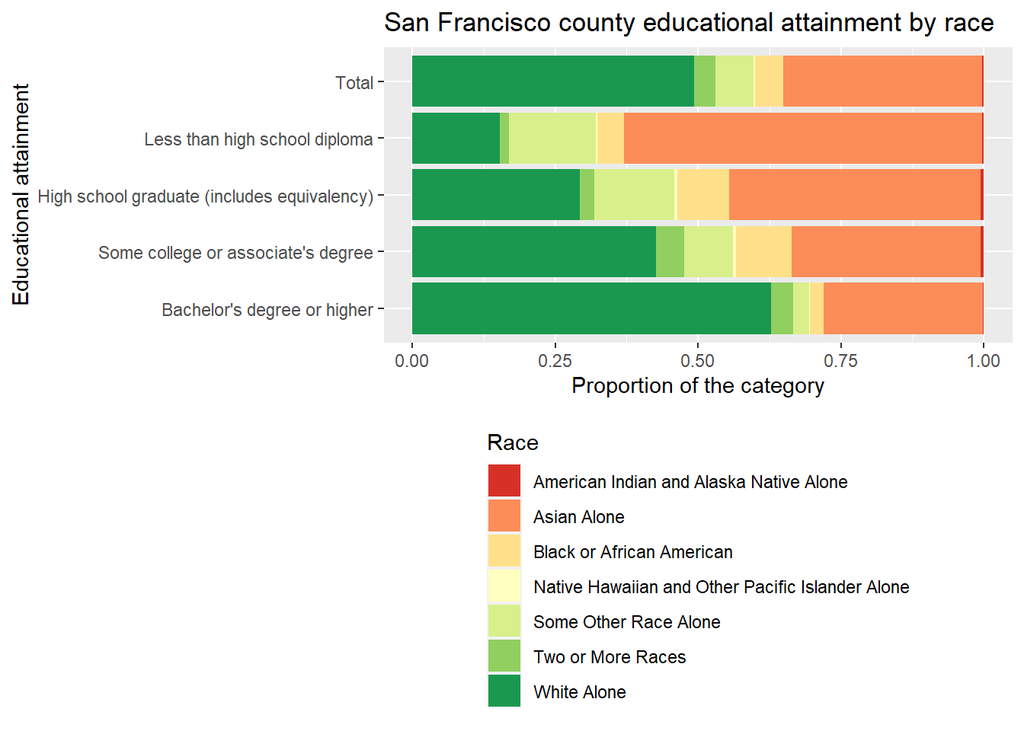

```r
sf_educ_race %>%
  group_by(EDUCATION, race) %>%
  summarize(estimate = sum(estimate)) %>%
  rbind(sf_educ_total) %>%
  ggplot() +
  geom_bar(
    aes(
      x = EDUCATION %>% factor(levels = rev(c("Total",sf_educ_race$EDUCATION[1:4]))),
      y = estimate,
      fill = race
    ),
    stat = "identity",
    position = "fill"
  ) +
  labs(
    x = "Educational attainment",
    y = "Proportion of the category",
    title = "San Francisco county educational attainment by race",
    fill = "Race"
  ) +
  coord_flip() +
  theme(
    legend.position = "bottom",
    legend.direction = "vertical"
  ) +
  scale_fill_brewer(palette="RdYlGn")
```

The **White Alone** and **Asian Alone** categories proportions have two opposite trends: the **White Alone** category proportion increases with the education attainment while the **Asian Alone** race proportion decreases. Compared to the global San Francisco county repartition, the **White Alone** category is much underrepresented in the educational attainment categories lower than *Some college or associate’s degree*, while the **Asian Alone** race is much overrepresented. The proportions of these two categories is the closest one to the total for the *Some college or associate’s degree* educational attainment. However, the balance is flipped for the *Bachelor’s degree or higher* level: the **White Alone** category is now overrepresented and the **Asian Alone** are underrepresented.

The **Some Other Race Alone** and **Black or African American** categories proportions have a same evolution for an educational attainment higher than *Less than high school diploma*: an overrepresentation in the *High school graduate (includes equivalency)* and *Some college or associate’s degree* levels, but a severe underrepresentation for the *Bachelor’s degree or higher* educational attainment (especially for the **Black or African American** population). I can also notice a much higher proportion of the **Some Other Race Alone** category among the *Less than high school diploma* educational attainment compared to its global proportion among the San Francisco county population.

As for the **Two or More Races** category, its representation compared to the global San Francisco county is: slightly lower in the *Less than high school diploma* level, roughly equal for the *High school graduate (includes equivalency)* and *Bachelor’s degree or higher* levels, slightly higher for the *Some college or associate’s degree* level.

Because of their very low proportions among the total population of the county, it is hard to raise trends for the **American Indian and Alaska Native Alone** and **Native Hawaiian and Other Pacific Islander Alone** categories. From the bar chart representation, I assume that the proportion of **Native Hawaiian and Other Pacific Islander Alone** is quite representative for every educational attainment. I assume the same for the **American Indian and Alaska Native Alone**, except for the *Bachelor’s degree or higher* level because this population seems to be unrepresented.

### Comparison with the Bay Area

Let’s compare the results obtained in the San Francisco county to the Bay Area by plotting equivalent bar charts. The only difference in the code is that I now extract data from all the counties in the Bay `region = "county:001,013,041,055,075,081,085,095,097"`.

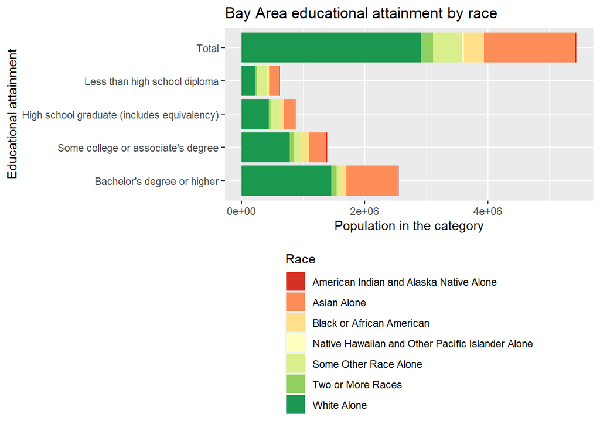

```r
bay_educ_race_compare <-
  1:7 %>%
  map_dfr(function(x){
    getCensus(
      name = "acs/acs5",
      vintage = 2018,
      region = "county:001,013,041,055,075,081,085,095,097",
      regionin = "state:06",
      vars = paste0("group(C15002",LETTERS[x],")")
    ) %>%
      select(!c(GEO_ID,state,NAME) & !ends_with(c("EA","MA","M"))) %>%
      pivot_longer(
        ends_with("E"),
        names_to = "variable",
        values_to = "estimate"
      ) %>%
      left_join(
        acs_vars_2018_5yr %>%
          select(name, label),
        by = c("variable" = "name")
      ) %>%
      select(-variable) %>%
      separate(
        label,
        into = c(NA,NA,'SEX','EDUCATION'),
        sep = "!!"
      ) %>%
      filter(!is.na(EDUCATION)) %>%
      mutate(race = census_race_labels[x])%>%
      select(
        !c(county,SEX)
      )
  })

bay_educ_total <-
  bay_educ_race_compare %>%
  group_by(race) %>%
  summarize(estimate = sum(estimate)) %>%
  mutate(EDUCATION = "Total")

saveRDS(bay_educ_total,'bay_educ_total.rds')

bay_educ_race_compare %>%
  group_by(EDUCATION, race) %>%
  summarize(estimate = sum(estimate)) %>%
  rbind(bay_educ_total) %>%
  ggplot() +
  geom_bar(
    aes(
      x = EDUCATION %>% factor(levels = rev(c("Total",bay_educ_race_compare$EDUCATION[1:4]))),
      y = estimate,
      fill = race
    ),
    stat = "identity",
    position = "stack"
  ) +
  labs(
    x = "Educational attainment",
    y = "Population in the category",
    title = "Bay Area educational attainment by race",
    fill = "Race"
  ) +
  coord_flip() +
  theme(
    legend.position = "bottom",
    legend.direction = "vertical"
  ) +
  scale_fill_brewer(palette="RdYlGn")
```

This graph shows that the global education attainment within the Bay Area is much more distributed than in the San Francisco county only.

Once again, it is pertinent to plot a filled bar chart using the `position = "fill"` argument to get information on the proportion of each race in every category instead of the total numbers.

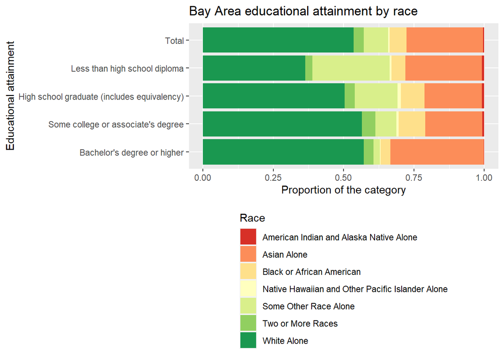

```r
bay_educ_race_compare %>%
  group_by(EDUCATION, race) %>%
  summarize(estimate = sum(estimate)) %>%
  rbind(bay_educ_total) %>%
  ggplot() +
  geom_bar(
    aes(
      x = EDUCATION %>% factor(levels = rev(c("Total",bay_educ_race_compare$EDUCATION[1:4]))),
      y = estimate,
      fill = race
    ),
    stat = "identity",
    position = "fill"
  ) +
  labs(
    x = "Educational attainment",
    y = "Proportion of the category",
    title = "Bay Area educational attainment by race",
    fill = "Race"
  ) +
  coord_flip() +
  theme(
    legend.position = "bottom",
    legend.direction = "vertical"
  ) +
  scale_fill_brewer(palette="RdYlGn")
```

I first notice that the **Asian Alone** category proportion is smaller among the Bay Area population than it is in the San Francisco county, while the **White Alone**, **Some Other Race Alone** and **Black or African American** categories proportions are slightly higher.

Compared to the San Francisco county’s educational attainment repartition, the **White Alone** and **Some Other Race Alone** categories proportions are much more important in the *Less than high school diploma* educational attainment, while the **Asian Alone** category is much less represented and **Black or African American** slightly less. However, these two last categories proportions in this educational attainment are roughly equivalent to their global proportion among the Bay Area educational system, while the **White Alone** category proportion is very low and the **Some Other Race Alone** proportion is very high.

In the *High school graduate* educational attainment, I observe the same patterns for the **White Alone** and **Asian Alone** categories proportions compared to the San Francisco county’s repartition. The **Some Other Race Alone** category proportion is still slightly disproportionate, and the **Black or African American** population proportion is also a bit higher than the global one. It is interesting to raise that the **Native Hawaiian and Other Pacific Islander Alone** category proportion is much higher compared to their global proportion in the Bay Area.

The *Some college or associate’s degree* educational attainment shows the closest repartition to the Bay Area’s. The only noticeable differences are the slightly higher proportions of the **Two or More Races** and **Black or African American** categories and the much lower proportion of the **Asian Alone** category. Compared to San Francisco county proportions in the same educational attainment, the **White Alone** race is still overrepresented and the **Asian Alone** population underrepresented.

### Conclusion on educational attainment

Before stating any conclusion, it is important to mention that the universe of the ACS datasets on educational attainment is “population 25 years or older”. Therefore, all the population 25 years or younger is not represented in these analysis. Part of it might be part - or is part when it comes to the *Less than high school diploma* - of the San Francisco county/Bay Area educational system. This is why the following assumptions may be proven wrong in the coming years depending on the evolution of the social diversity and inequities.

The San Francisco county shows a much more unequal educational attainment by race than the global Bay Area. The bar chart is much less centered and shows a linear variation instead; the **White Alone** race has a much higher educational attainment compared to the **Some Other Race Alone** and **Black or African American** categories while the **Asian Alone** category is less and less represented when the level of education increases. This same underrepresentation of the **Some Other Race Alone** and **Black or African American** populations among the highest educational attainment can be observed in the whole Bay Area, but the **White Alone** race representation is closest to its actual proportion of the population and the **Asian Alone** is a bit overrepresented, which is an indicator of social inclusion.

## K-12 students who have no internet access at home

The next step of my analysis consists in reviewing the impact of housing location and the ability to access internet for K-12 students (from kindergarten to 12th grade). Having an internet access is essential to a proper learning, especially during the COVID-19 pandemic because remote learning has become necessary.

Even in usual circumstances, an internet access at home is even more for young students. First, because it is the first source of information available and some assignments might be asked to be worked on or sent via internet, but also because they might not have the opportunity to find a free public internet access outside home (cafes, libraries…) for safety or mobility reasons.

### In San Francisco county

Let’s first plot the map of the percentage of K-12 students with no internet access at home in the San Francisco county. I used the `get_pums()` function to extract the PUMS files from the 2019-1yr ACS:

```
census_api_key("c8aa67e4086b4b5ce3a8717f59faa9a28f611dab")
ca_pums <- get_pums(
  variables = c(
    "PUMA",
    "NP",
    "SCHG",
    "ACCESS"
  ),
  state = "CA",
  year = 2019,
  survey = "acs1",
  recode = T
)
```

Using the [PUMS Data dictionnary](https://www2.census.gov/programs-surveys/acs/tech_docs/pums/data_dict/PUMS_Data_Dictionary_2019.pdf), I can then identify and merge the K-12 students with no internet access at home according to their PUMA codes, then plot the map using the `leaflet()` function. To be able to display both the percentages and numbers of K-12 students, I created my own label `SF_label` using the `sprintf()` and `lapply(htmltools::HTML)` functions:

```r
ca_pumas <-
  pumas("CA", cb = T, progress_bar = F)

ca_counties <- counties("CA", cb = T, progress_bar = F)
SF_county_names <-
  c(
    "San Francisco"
  )
SF_counties <-
  ca_counties %>%
  filter(NAME %in% SF_county_names)

ca_cities <- places("CA", cb = T, progress_bar = FALSE)
SF_cities <- ca_cities[SF_counties, ]
SF_cities_within <-
  ca_cities %>%
  st_centroid() %>%
  .[SF_counties, ] %>%
  st_set_geometry(NULL) %>%
  left_join(ca_cities %>% select(GEOID)) %>%
  st_as_sf()

SF_cities_within <-
  ca_cities[which(ca_cities$GEOID %in% st_centroid(ca_cities)[SF_counties, ]$GEOID), ]

usa_zips <-
  zctas(cb = T, progress_bar = F)

SF_zips <-
  usa_zips %>%
  st_centroid() %>%
  .[SF_counties, ] %>%
  st_set_geometry(NULL) %>%
  left_join(usa_zips %>% select(GEOID10)) %>%
  st_as_sf()


SF_pumas <-
  ca_pumas %>%
  st_centroid() %>%
  .[SF_counties, ] %>%
  st_set_geometry(NULL) %>%
  left_join(ca_pumas %>% select(GEOID10)) %>%
  st_as_sf()

SF_pumas$PUMACE10<-as.numeric(SF_pumas$PUMACE10)

SF_pums <-
  ca_pums %>%
  filter(PUMA %in% SF_pumas$PUMACE10)

SF_pums$PUMA<-as.numeric(SF_pums$PUMA)

SF_pums_K12_nointernet <-
  SF_pums %>%
  mutate(
    K12_nointernet = ifelse(
        (ACCESS == 3) &
        (SCHG %in% 2:14),
      PWGTP,
      0
    )
  ) %>%
  group_by(PUMA) %>%
  summarize(
    K12_nointernet_per =
      sum(K12_nointernet*as.numeric(SPORDER), na.rm =T)/sum(PWGTP, na.rm = T)*100,
    K12_nointernet_tot = sum(K12_nointernet, na.rm =T),
    K12_tot = (K12_nointernet_tot*100)/K12_nointernet_per
  ) %>%
  left_join(
    SF_pumas %>%
      select(PUMACE10),
    by = c("PUMA" = "PUMACE10")
  ) %>%
  st_as_sf()

SF_pums_pal_per <- colorNumeric(
  palette = "YlOrRd",
  domain = SF_pums_K12_nointernet$K12_nointernet_per
)

SF_labels_per <- sprintf(
  "<strong>%s%%</strong><br/>%g students",
  round(SF_pums_K12_nointernet$K12_nointernet_per, digits = 2), SF_pums_K12_nointernet$K12_nointernet_tot
) %>% lapply(htmltools::HTML)

leaflet() %>%
  addTiles() %>%
  addPolygons(
    data = SF_pums_K12_nointernet,
    fillColor = ~SF_pums_pal_per(K12_nointernet_per),
    color = "white",
    opacity = 0.7,
    fillOpacity = 0.7,
    weight = 1,
    label = SF_labels_per,
    highlightOptions = highlightOptions(
      weight = 2,
      opacity = 1
    )
  ) %>%
  addLegend(
    data = SF_pums_K12_nointernet,
    pal = SF_pums_pal_per,
    values = ~K12_nointernet_per,
    title = "% K-12 students<br>no internet access<br>at home"
  )
```

[interactive chart not shown]

For the following comments, I will define the San Francisco county’s geography as follows:

- **Middle (Mid) SF**: Le Castro, Bernal Heights and Haight-Ashbury
- **South-East (S-E) SF**: Portola, Hunters Point, Visitacion Valley and Excelsior District
- **South-West (S-W) SF**: Merced and Westwood areas
- **West (W) SF**: Sunset District and Forest Hill
- **North-West (N-W) SF**: Richmond District
- **North-East (N-E) SF**: Financial District, North Beach and Treasure Island
- **East (E) SF**: Mission District and Dogpatch

I observe three different patterns: in the W, S-W and Mid SF, all K-12 students have an internet access at home. In the top part of the county (N-W, N-E and E SF), a majority of K-12 students have an internet access at home, but there is nonetheless 269 students not benefiting from it in this area. The S-E SF clearly stands out from the other counties. The map shows a much higher percentage of K-12 students with no internet access at home (2.54%) than the other areas.

I find it interesting to put these numbers in perspective with the total number of K-12 students in each part of the county to have a real perspective on the issue. In my opinion, using the percentage data is not adapted to the San Francisco county because he is much smaller than the other counties in the Bay. Therefore, the surface covered by one of its section is also much smaller than in the others. Analyzing percentages is relevant when there is a huge difference in student populations between the sections of a county due to the concentration of educational institutions, because it takes into account the concentration of student population in a defined area. Here, the areas borders are so closed to each other that a K-12 student might be studying in another section than the one he is living in. A quick argument is that if 61 students represent 0.12% of the N-W SF K-12 student population, then the 618 students with no internet access at home in the S-E SF would have represented only 1.21% of the N-W SF K-12 student population, when it represents more than 2.5% in the S-E area.

It makes me think that this is in fact a problem of neighborhood inequalities that leads to inequalities in education. This is why I chose to plot the same map but using the total number of K-12 students with no internet access at home as scale instead of the percentage to support my idea:

```r
SF_pums_pal_tot <- colorNumeric(
  palette = "YlOrRd",
  domain = SF_pums_K12_nointernet$K12_nointernet_tot
)

SF_pums_K12_nointernet$K12_tot[is.nan(SF_pums_K12_nointernet$K12_tot)]<-0

SF_labels_tot <- sprintf(
  "<strong>%s out of %s students</strong>",
  SF_pums_K12_nointernet$K12_nointernet_tot,round(SF_pums_K12_nointernet$K12_tot, digits=0), round(SF_pums_K12_nointernet$K12_nointernet_per, digits = 2)
) %>% lapply(htmltools::HTML)

leaflet() %>%
  addTiles() %>%
  addPolygons(
    data = SF_pums_K12_nointernet,
    fillColor = ~SF_pums_pal_tot(K12_nointernet_tot),
    color = "white",
    opacity = 0.7,
    fillOpacity = 0.7,
    weight = 1,
    label = SF_labels_tot,
    highlightOptions = highlightOptions(
      weight = 2,
      opacity = 1
    )
  ) %>%
  addLegend(
    data = SF_pums_K12_nointernet,
    pal = SF_pums_pal_tot,
    values = ~K12_nointernet_tot,
    title = "Number of K-12 students<br>no internet access<br>at home"
  )
```

[interactive chart not shown]

I think this map allows to better visualize the differences and inequalities among the different areas of the county. In fact, the top part of the county clearly stands out from the W/S-W/Mid part of the county. The S-E part of SF still appears to have much more K-12 students with no internet access at home than the others.

To conclude, I wanted to highlight through the specific study of the San Francisco county that the inequalities in the access to education (here symbolized by an internet access at home) are directly related to neighborhood inequalities. According to the [Bloomberg CityLab](https://www.bloomberg.com/news/articles/2016-12-09/the-persistent-inequality-of-neighborhoods#:~:text=In%20other%20words%2C%20America's%20neighborhood,worsening%20precariousness%20in%20the%20middle.), these consist in “the juxtaposition of concentrated disadvantage and concentrated advantage at the extremes”. Here, the S-E SF clearly suffers from these inequalities, and the K-12 students living in this area might be impacted in their ability to pursue higher level studies, or even succeed in the on they are enrolled in.

### In the Bay Area

Let’s now visualize the repartition of K-12 students with no internet access at home in the Bay Area to see if we can identify several same patterns among the different counties:

```r
ca_pumas <-
  pumas("CA", cb = T, progress_bar = F)

ca_counties <- counties("CA", cb = T, progress_bar = F)
bay_county_names <-
  c(
    "Alameda",
    "Contra Costa",
    "Marin",
    "Napa",
    "San Francisco",
    "San Mateo",
    "Santa Clara",
    "Solano",
    "Sonoma"
  )
bay_counties <-
  ca_counties %>%
  filter(NAME %in% bay_county_names)

ca_cities <- places("CA", cb = T, progress_bar = FALSE)
bay_cities <- ca_cities[bay_counties, ]
bay_cities_within <-
  ca_cities %>%
  st_centroid() %>%
  .[bay_counties, ] %>%
  st_set_geometry(NULL) %>%
  left_join(ca_cities %>% select(GEOID)) %>%
  st_as_sf()

bay_cities_within <-
  ca_cities[which(ca_cities$GEOID %in% st_centroid(ca_cities)[bay_counties, ]$GEOID), ]

usa_zips <-
  zctas(cb = T, progress_bar = F)

bay_zips <-
  usa_zips %>%
  st_centroid() %>%
  .[bay_counties, ] %>%
  st_set_geometry(NULL) %>%
  left_join(usa_zips %>% select(GEOID10)) %>%
  st_as_sf()


bay_pumas <-
  ca_pumas %>%
  st_centroid() %>%
  .[bay_counties, ] %>%
  st_set_geometry(NULL) %>%
  left_join(ca_pumas %>% select(GEOID10)) %>%
  st_as_sf()

bay_pumas$PUMACE10<-as.numeric(bay_pumas$PUMACE10)

bay_pums <-
  ca_pums %>%
  filter(PUMA %in% bay_pumas$PUMACE10)

bay_pums$PUMA<-as.numeric(bay_pums$PUMA)

bay_pums_K12_nointernet <-
  bay_pums %>%
  mutate(
    K12_nointernet = ifelse(
        (ACCESS == 3) &
        (SCHG %in% 2:14),
      PWGTP,
      0
    )
  ) %>%
  group_by(PUMA) %>%
  summarize(
    K12_nointernet_per =
      sum(K12_nointernet*as.numeric(SPORDER), na.rm =T)/(sum(PWGTP, na.rm = T))*100,
    K12_nointernet_tot=
      sum(K12_nointernet, na.rm =T),
    K12_tot = (K12_nointernet_tot*100)/K12_nointernet_per
  ) %>%
  left_join(
    bay_pumas %>%
      select(PUMACE10),
    by = c("PUMA" = "PUMACE10")
  ) %>%
  st_as_sf()

pums_pal <- colorNumeric(
  palette = "YlOrRd",
  domain = bay_pums_K12_nointernet$K12_nointernet_per
)

bay_labels <- sprintf(
  "<strong>%s%%</strong><br/>%g students",
  round(bay_pums_K12_nointernet$K12_nointernet_per, digits = 2), bay_pums_K12_nointernet$K12_nointernet_tot
) %>% lapply(htmltools::HTML)

leaflet() %>%
  addTiles() %>%
  addPolygons(
    data = bay_pums_K12_nointernet,
    fillColor = ~pums_pal(K12_nointernet_per),
    color = "white",
    opacity = 0.7,
    fillOpacity = 0.7,
    weight = 1,
    label = bay_labels,
    highlightOptions = highlightOptions(
      weight = 2,
      opacity = 1
    )
  ) %>%
  addLegend(
    data = bay_pums_K12_nointernet,
    pal = pums_pal,
    values = ~K12_nointernet_per,
    title = "% K-12 students<br>no internet access<br>at home"
  )
```

[interactive chart not shown]

This map shows clear disparities among the different counties in the Bay Area. The San Francisco county studied before appears to have the lowest percentages of K-12 students with no internet access at home, and the Alameda county (especially South-Eastern Oakland) clearly stands out from the other areas in the Bay. This is why I will isolate the Alameda county for a dedicated part and will analyze the global Bay without this county instead. In fact, the very high percentage (13.93%) does not allow a porper visualization of the contrasts among the other counties/regions.

```r
ca_pumas <-
  pumas("CA", cb = T, progress_bar = F)

ca_counties <- counties("CA", cb = T, progress_bar = F)
bay_no_ala_county_names <-
  c(
    "Contra Costa",
    "Marin",
    "Napa",
    "San Francisco",
    "San Mateo",
    "Santa Clara",
    "Solano",
    "Sonoma"
  )
bay_no_ala_counties <-
  ca_counties %>%
  filter(NAME %in% bay_no_ala_county_names)

ca_cities <- places("CA", cb = T, progress_bar = FALSE)
bay_no_ala_cities <- ca_cities[bay_no_ala_counties, ]
bay_no_ala_cities_within <-
  ca_cities %>%
  st_centroid() %>%
  .[bay_no_ala_counties, ] %>%
  st_set_geometry(NULL) %>%
  left_join(ca_cities %>% select(GEOID)) %>%
  st_as_sf()

bay_no_ala_cities_within <-
  ca_cities[which(ca_cities$GEOID %in% st_centroid(ca_cities)[bay_no_ala_counties, ]$GEOID), ]

usa_zips <-
  zctas(cb = T, progress_bar = F)

bay_no_ala_zips <-
  usa_zips %>%
  st_centroid() %>%
  .[bay_no_ala_counties, ] %>%
  st_set_geometry(NULL) %>%
  left_join(usa_zips %>% select(GEOID10)) %>%
  st_as_sf()


bay_no_ala_pumas <-
  ca_pumas %>%
  st_centroid() %>%
  .[bay_no_ala_counties, ] %>%
  st_set_geometry(NULL) %>%
  left_join(ca_pumas %>% select(GEOID10)) %>%
  st_as_sf()

bay_no_ala_pumas$PUMACE10<-as.numeric(bay_no_ala_pumas$PUMACE10)

bay_no_ala_pums <-
  ca_pums %>%
  filter(PUMA %in% bay_no_ala_pumas$PUMACE10)

bay_no_ala_pums$PUMA<-as.numeric(bay_no_ala_pums$PUMA)

bay_no_ala_pums_K12_nointernet <-
  bay_no_ala_pums %>%
  mutate(
    K12_nointernet = ifelse(
        (ACCESS == 3) &
        (SCHG %in% 2:14),
      PWGTP,
      0
    )
  ) %>%
  group_by(PUMA) %>%
  summarize(
    K12_nointernet_per =
      sum(K12_nointernet*as.numeric(SPORDER), na.rm =T)/(sum(PWGTP, na.rm = T))*100,
    K12_nointernet_tot=
      sum(K12_nointernet, na.rm =T),
    K12_tot = (K12_nointernet_tot*100)/K12_nointernet_per
  ) %>%
  left_join(
    bay_no_ala_pumas %>%
      select(PUMACE10),
    by = c("PUMA" = "PUMACE10")
  ) %>%
  st_as_sf()

pums_pal <- colorNumeric(
  palette = "YlOrRd",
  domain = bay_no_ala_pums_K12_nointernet$K12_nointernet_per
)

bay_no_ala_labels <- sprintf(
  "<strong>%s%%</strong><br/>%g students",
  round(bay_no_ala_pums_K12_nointernet$K12_nointernet_per, digits = 2), bay_no_ala_pums_K12_nointernet$K12_nointernet_tot
) %>% lapply(htmltools::HTML)

leaflet() %>%
  addTiles() %>%
  addPolygons(
    data = bay_no_ala_pums_K12_nointernet,
    fillColor = ~pums_pal(K12_nointernet_per),
    color = "white",
    opacity = 0.7,
    fillOpacity = 0.7,
    weight = 1,
    label = bay_no_ala_labels,
    highlightOptions = highlightOptions(
      weight = 2,
      opacity = 1
    )
  ) %>%
  addLegend(
    data = bay_no_ala_pums_K12_nointernet,
    pal = pums_pal,
    values = ~K12_nointernet_per,
    title = "% K-12 students<br>no internet access<br>at home"
  )
```

[interactive chart not shown]

The map now reveals much more about the inequalities in internet access at home for K-12 students in the Bay. In fact, I can notice three patterns:

- The suburban areas of big cities are much unprivileged compared to the center. San Jose clearly pictures this phenomenon: the center of the city has no K-12 students with no internet access at home, while the suburbs regroup more than 3000 unprivileged K-12 students.
- Poorer cities adjacent to very rich cities also show high percentages. For example, Redwood City and San Carlos have much higher numbers than Palo Alto and Mountain View. Additionally, it could be interesting to have more insight of the local repartition of these students. In fact, North Palo Alto has a high percentage, but I would like to be able to know if the students with no internet access at home live close to the border with Redwood City or not. San Rafael also have very high percentages compared to North San Francisco and Richmond.
- Cities far from the economical center of the Bay are also much unprivileged. The cities of Vacaville, Dixon, Santa Rosa, Morgan Hill et Gilroy clearly highlight this phenomenon.

These patterns raise the issue of a vicious circle when it comes to inequalities among cities: the richer a city gets (in terms of job opportunities and economic activity), the better the offer for education is (because the infrastructures are adapted accordingly), the more expensive the housing becomes (because of the elevation of living standards), and eventually the city becomes even richer.

However, as I mentioned before, the Alameda county clearly shows very high percentages while none of these patterns seem to be applicable here. This is why I will further analyze the case of Alameda county in the following part in order to put it in perspective with the results obtained for the San Francisco county.

### Comparison with Alameda county

The following map shows the percentage of K-12 students with no internet access at home in the Alameda and San Francisco counties:

```r
ca_pumas <-
  pumas("CA", cb = T, progress_bar = F)

ca_counties <- counties("CA", cb = T, progress_bar = F)
Ala_SF_county_names <-
  c(
    "Alameda",
    "San Francisco"
  )
Ala_SF_counties <-
  ca_counties %>%
  filter(NAME %in% Ala_SF_county_names)

ca_cities <- places("CA", cb = T, progress_bar = FALSE)
Ala_SF_cities <- ca_cities[Ala_SF_counties, ]
Ala_SF_cities_within <-
  ca_cities %>%
  st_centroid() %>%
  .[Ala_SF_counties, ] %>%
  st_set_geometry(NULL) %>%
  left_join(ca_cities %>% select(GEOID)) %>%
  st_as_sf()

Ala_SF_cities_within <-
  ca_cities[which(ca_cities$GEOID %in% st_centroid(ca_cities)[Ala_SF_counties, ]$GEOID), ]

usa_zips <-
  zctas(cb = T, progress_bar = F)

Ala_SF_zips <-
  usa_zips %>%
  st_centroid() %>%
  .[Ala_SF_counties, ] %>%
  st_set_geometry(NULL) %>%
  left_join(usa_zips %>% select(GEOID10)) %>%
  st_as_sf()


Ala_SF_pumas <-
  ca_pumas %>%
  st_centroid() %>%
  .[Ala_SF_counties, ] %>%
  st_set_geometry(NULL) %>%
  left_join(ca_pumas %>% select(GEOID10)) %>%
  st_as_sf()

Ala_SF_pumas$PUMACE10<-as.numeric(Ala_SF_pumas$PUMACE10)

Ala_SF_pums <-
  ca_pums %>%
  filter(PUMA %in% Ala_SF_pumas$PUMACE10)

Ala_SF_pums$PUMA<-as.numeric(Ala_SF_pums$PUMA)

Ala_SF_pums_K12_nointernet <-
  Ala_SF_pums %>%
  mutate(
    K12_nointernet = ifelse(
        (ACCESS == 3) &
        (SCHG %in% 2:14),
      PWGTP,
      0
    )
  ) %>%
  group_by(PUMA) %>%
  summarize(
    K12_nointernet_per =
      sum(K12_nointernet*as.numeric(SPORDER), na.rm =T)/sum(PWGTP, na.rm = T)*100,
    K12_nointernet_tot = sum(K12_nointernet, na.rm =T),
    K12_tot = (K12_nointernet_tot*100)/K12_nointernet_per
  ) %>%
  left_join(
    Ala_SF_pumas %>%
      select(PUMACE10),
    by = c("PUMA" = "PUMACE10")
  ) %>%
  st_as_sf()

Ala_SF_pums_pal_per <- colorNumeric(
  palette = "YlOrRd",
  domain = Ala_SF_pums_K12_nointernet$K12_nointernet_per
)

Ala_SF_labels_per <- sprintf(
  "<strong>%s%%</strong><br/>%g students",
  round(Ala_SF_pums_K12_nointernet$K12_nointernet_per, digits = 2), Ala_SF_pums_K12_nointernet$K12_nointernet_tot
) %>% lapply(htmltools::HTML)

leaflet() %>%
  addTiles() %>%
  addPolygons(
    data = Ala_SF_pums_K12_nointernet,
    fillColor = ~Ala_SF_pums_pal_per(K12_nointernet_per),
    color = "white",
    opacity = 0.7,
    fillOpacity = 0.7,
    weight = 1,
    label = Ala_SF_labels_per,
    highlightOptions = highlightOptions(
      weight = 2,
      opacity = 1
    )
  ) %>%
  addLegend(
    data = Ala_SF_pums_K12_nointernet,
    pal = Ala_SF_pums_pal_per,
    values = ~K12_nointernet_per,
    title = "% K-12 students<br>no internet access<br>at home"
  )
```

[interactive chart not shown]

The South-Eastern part of Oakland city stands out on this map: nearly 14% of the K-12 students here have no internet access at home. The second highest percentage amounts to “only” 2.62% (Dublin, Pleasanton and Livermore area). As for the San Francisco county, I will plot the map showing the total numbers instead of percentages to visualize the inequalities more efficiently at a local scale.

```r
ca_pumas <-
  pumas("CA", cb = T, progress_bar = F)

ca_counties <- counties("CA", cb = T, progress_bar = F)
other_county_names <-
  c(
    "Alameda",
    "San Francisco"
  )
other_counties <-
  ca_counties %>%
  filter(NAME %in% other_county_names)

ca_cities <- places("CA", cb = T, progress_bar = FALSE)
other_cities <- ca_cities[other_counties, ]
other_cities_within <-
  ca_cities %>%
  st_centroid() %>%
  .[other_counties, ] %>%
  st_set_geometry(NULL) %>%
  left_join(ca_cities %>% select(GEOID)) %>%
  st_as_sf()

other_cities_within <-
  ca_cities[which(ca_cities$GEOID %in% st_centroid(ca_cities)[other_counties, ]$GEOID), ]

usa_zips <-
  zctas(cb = T, progress_bar = F)

other_zips <-
  usa_zips %>%
  st_centroid() %>%
  .[other_counties, ] %>%
  st_set_geometry(NULL) %>%
  left_join(usa_zips %>% select(GEOID10)) %>%
  st_as_sf()


other_pumas <-
  ca_pumas %>%
  st_centroid() %>%
  .[other_counties, ] %>%
  st_set_geometry(NULL) %>%
  left_join(ca_pumas %>% select(GEOID10)) %>%
  st_as_sf()

other_pumas$PUMACE10<-as.numeric(other_pumas$PUMACE10)

other_pums <-
  ca_pums %>%
  filter(PUMA %in% other_pumas$PUMACE10)

other_pums$PUMA<-as.numeric(other_pums$PUMA)

other_pums_K12_nointernet <-
  other_pums %>%
  mutate(
    K12_nointernet = ifelse(
        (ACCESS == 3) &
        (SCHG %in% 2:14),
      PWGTP,
      0
    )
  ) %>%
  group_by(PUMA) %>%
  summarize(
    K12_nointernet_per =
      sum(K12_nointernet*as.numeric(SPORDER), na.rm =T)/sum(WGTP, na.rm = T)*100,
    K12_nointernet_tot =
      sum(K12_nointernet, na.rm =T),
    K12_tot = (K12_nointernet_tot*100)/K12_nointernet_per
  ) %>%
  left_join(
    other_pumas %>%
      select(PUMACE10),
    by = c("PUMA" = "PUMACE10")
  ) %>%
  st_as_sf()

other_pums_pal_tot <- colorNumeric(
  palette = "YlOrRd",
  domain = other_pums_K12_nointernet$K12_nointernet_tot
)

other_pums_K12_nointernet$K12_tot[is.nan(other_pums_K12_nointernet$K12_tot)]<-0

other_labels_tot <- sprintf(
  "<strong>%s out of %s students</strong>",
  other_pums_K12_nointernet$K12_nointernet_tot,round(other_pums_K12_nointernet$K12_tot,digits = 0), round(other_pums_K12_nointernet$K12_nointernet_per, digits = 2)
) %>% lapply(htmltools::HTML)

leaflet() %>%
  addTiles() %>%
  addPolygons(
    data = other_pums_K12_nointernet,
    fillColor = ~other_pums_pal_tot(K12_nointernet_tot),
    color = "white",
    opacity = 0.7,
    fillOpacity = 0.7,
    weight = 1,
    label = other_labels_tot,
    highlightOptions = highlightOptions(
      weight = 2,
      opacity = 1
    )
  ) %>%
  addLegend(
    data = other_pums_K12_nointernet,
    pal = other_pums_pal_tot,
    values = ~K12_nointernet_tot,
    title = "Number of K-12 students<br>no internet access<br>at home"
  )
```

[interactive chart not shown]

Inequalities are more highlighted on this map. In fact, there are more K-12 students with no internet access at home in South-Eastern Oakland only, than in all the others area regrouped: 4,960 students in South-Eastern Oakland for 4,873 in the other areas (50.44% of the total only in South-Eastern Oakland). In fact, San Francisco county appears to offer a much more universal access to internet access at home for K-12 students: the total number of K-12 students with no internet access at home in South-Eastern Oakland (4,960) is more than five times higher than the total number in the San Francisco county (887). Overall, the total number of K-12 students with no internet access at home in the Alameda county (9,833) is more than 10 times higher than the total in the San Francisco county.

An interesting data that I cannot plot here is the total number of K-12 students in the two counties, because I compute the total by multiplying the percentages, which can be equal to zero, resulting in a total number of students of zero.

### Conclusion on housing location and the ability to access internet for K-12 students

This in-depth analysis of the repartition of K-12 students with no internet access at home allowed me to consider reoccurring patterns on different scales:

- At city level, the San Francisco county proves that there can be huge differences in internet access availability between two adjacent neighborhoods
- At county level, cities such as Oakland shows that a single city can regroup a huge part of all the K-12 students with no internet access at home
- At the Bay Area level, most of the K-12 students with no internet access at home are regrouped in counties/cities accordingly to very precise criteria: distance from the center of the city, distance from another rich city and distance from the economical center of the Bay.

Overall, the number of K-12 students with no internet access at home therefore appears to be a good indicator of social inequality among a population and a defined area; an internet access is essential to succeed in or even attend an academic curriculum, especially during the COVID-19 pandemic. While it was an incredible tool to get help or information, internet is now vital to be able to follow remote lessons, especially synchronous ones. Unfortunately, the highest percentages in the previous analyses occurred in the poorest areas of the Bay, which constitutes a vicious circle: children from poorest families don’t have all the tools required to properly follow their lessons, and therefore have lower chances to get a high educational attainment. It becomes then even more difficult for them to access higher incomes jobs.

## Educational mobility

The final step of my analysis consists in analyzing the educational mobility by educational attainment in the San Francisco county. Because I spent some time commenting on the Alameda county’s situation in my previous part, I will do the same here to see if I can see significant results. I will also compare the results with a county that showed very low percentages and numbers of students with no internet access at home (Solano County).

### In San Francisco county

- **Internal net**: Educational mobility from inside the county.
  - A positive **Internal net** for a certain educational attainment could mean that people within the county have increased their education level (got a degree, graduated…), or a higher number of answers to the ACS between 2019 and the previous years.
  - A negative **Internal net** should be the consequence of a positive one and the two should balance (except for unusual cases such as deceases).
- **External net**: Educational mobility coming from outside the county.
  - A positive **External net** for a certain educational attainment means that people with this level of education have settled in the county.
  - A negative **External net** for a certain educational attainment means that people with this level of education have left in the county.

```r
library(tidyverse)
library(censusapi)

Sys.setenv(CENSUS_KEY="c8aa67e4086b4b5ce3a8717f59faa9a28f611dab")

acs_vars_2019_1yr <-
  listCensusMetadata(
    name = "2019/acs/acs1",
    type = "variables"
  )

sf_mobility_educ_current_19 <-
  getCensus(
    name = "acs/acs1",
    vintage = 2019,
    region = "county:075",
    regionin = "state:06",
    vars = c("group(B07009)")
  ) %>%
  select(!c(GEO_ID,state,NAME) & !ends_with(c("EA","MA","M"))) %>%
  pivot_longer(
    ends_with("E"),
    names_to = "variable",
    values_to = "estimate"
  ) %>%
  left_join(
    acs_vars_2019_1yr %>%
      select(name, label),
    by = c("variable" = "name")
  ) %>%
  select(-variable) %>%
  separate(
    label,
    into = c(NA,NA,"mobility","education"),
    sep = "!!"
  ) %>%
  mutate(
    mobility = ifelse(
      mobility %in% c("Same house 1 year ago:", "Moved within same county:"),
      "Here since last year",
      "Inflow"
    )
  ) %>%
  filter(!is.na(education)) %>%
  group_by(mobility, education) %>%
  summarize(estimate = sum(estimate))


sf_mobility_educ_lastyear_19 <-
  getCensus(
    name = "acs/acs1",
    vintage = 2019,
    region = "county:075",
    regionin = "state:06",
    vars = c("group(B07409)")
  ) %>%
  select(!c(GEO_ID,state,NAME) & !ends_with(c("EA","MA","M"))) %>%
  pivot_longer(
    ends_with("E"),
    names_to = "variable",
    values_to = "estimate"
  ) %>%
  left_join(
    acs_vars_2019_1yr %>%
      select(name, label),
    by = c("variable" = "name")
  ) %>%
  select(-variable) %>%
  separate(
    label,
    into = c(NA,NA,"mobility","education"),
    sep = "!!"
  ) %>%
  mutate(
    mobility = ifelse(
      mobility %in% c("Same house:", "Moved within same county:"),
      "Here since last year",
      "Outflow"
    )
  ) %>%
  filter(!is.na(education)) %>%
  group_by(mobility, education) %>%
  summarize(estimate = sum(estimate))


sf_mobility_educ_current_18 <-
  getCensus(
    name = "acs/acs1",
    vintage = 2018,
    region = "county:075",
    regionin = "state:06",
    vars = c("group(B07009)")
  ) %>%
  select(!c(GEO_ID,state,NAME) & !ends_with(c("EA","MA","M"))) %>%
  pivot_longer(
    ends_with("E"),
    names_to = "variable",
    values_to = "estimate"
  ) %>%
  left_join(
    acs_vars_2019_1yr %>%
      select(name, label),
    by = c("variable" = "name")
  ) %>%
  select(-variable) %>%
  separate(
    label,
    into = c(NA,NA,"mobility","education"),
    sep = "!!"
  ) %>%
  mutate(
    mobility = "Here last year"
  ) %>%
  filter(!is.na(education)) %>%
  group_by(mobility, education) %>%
  summarize(estimate = sum(estimate))

sf_flows_19 <-
  rbind(
    sf_mobility_educ_current_18,
    sf_mobility_educ_lastyear_19 %>%
      filter(mobility == "Outflow"),
    sf_mobility_educ_current_19 %>%
      filter(mobility == "Inflow"),
    sf_mobility_educ_current_19 %>%
      group_by(education) %>%
      summarize(estimate = sum(estimate)) %>%
      mutate(mobility = "Here this year")
  ) %>%
  pivot_wider(
    names_from = mobility,
    values_from = estimate
  ) %>%
  mutate(
    `External net` = Inflow - Outflow,
    `Internal net` = `Here this year` - `Here last year` - `External net`,
  ) %>%
  mutate(education =  factor(education, levels = c("Bachelor's degree","Graduate or professional degree","Some college or associate's degree","High school graduate (includes equivalency)","Less than high school graduate"))
  )%>%
  arrange(education) %>%
  select(
    `Educational attaintment` = education,
    `Internal net`,
    `External net`,
    `Here last year`,
    `Here this year`,
    Outflow,
    Inflow
  )

datatable(
  sf_flows_19,
  rownames = FALSE,
  caption = htmltools::tags$caption(
    style = 'caption-side: bottom; text-align: center;',
    'Educational mobility in the San Francisco county')
  )
```

| Educational attaintment | Internal net | External net | Here last year | Here this year | Outflow | Inflow |
| --- | --- | --- | --- | --- | --- | --- |
| Bachelor's degree | -828 | -6881 | 253594 | 245885 | 24630 | 17749 |
| Graduate or professional degree | 3938 | -1435 | 166736 | 169239 | 16487 | 15052 |
| Some college or associate's degree | 823 | -2490 | 123004 | 121337 | 7358 | 4868 |
| High school graduate (includes equivalency) | -3363 | 792 | 85850 | 83279 | 3705 | 4497 |
| Less than high school graduate | 10171 | -2013 | 73381 | 81539 | 3894 | 1881 |

First, I assume that the high **Internal net** for the *Less than High school graduate* is mainly due to the new enrollments for young students. The **Internal net** values for the other educational attainment categories add up to a total of +570. As mentioned before, it is quite close to a break-even; the *Bachelor degrees* and *High school graduate (includes equivalency)* categories show a negative **Internal net** leading to a positive one for the *Graduate or professional degree* and *Some college or associate’s degree*. The fact that the **Internal net** is slightly higher than 0 might be due to several factors, such as a higher number of people answering the ACS in 2019 compared to 2018 and the previous years.

The **External net** is however extremely negative (-12,027 in total), especially among the *Bachelor degrees* (-6,881, representing more than 50% of the global leavings). Many reasons can lead to such a result. First, the high rent price of housing in the San Francisco county might force the students to live outside the county to pursue their studies there. Also, students willing to pursue higher level studies might suffer from a lack of educational institutions among the county, forcing them to move to an other one. Because the *Bachelor degrees* category is the one with the extreme negative **External net** value, I may conclude that it is mainly due to a a lack of educational institutions.

In fact, the San Francisco county is proportionally very small compared to its student population. Therefore, there are two possibilities: there is not enough place for every students willing to pursue higher level studies, or the reputation of the institutions is not good enough to attract the students. This last possibility is even more relevant because of the housing price in the county: high level studies are very expensive and time-consuming, so accumulate the tuition fees with a high rent could be impossible for a standard student.

### Comparison with the Alameda county

I will use exactly the same definitions for my analysis of the Alameda county’s educational mobility. The only difference in the code will be the name of the variables and the region code (`region = "county:001"`). I also use the same definition of **Internal** and **External net** as for the San Francisco county.

```r
acs_vars_2019_1yr <-
  listCensusMetadata(
    name = "2019/acs/acs1",
    type = "variables"
  )

ala_mobility_educ_current_19 <-
  getCensus(
    name = "acs/acs1",
    vintage = 2019,
    region = "county:001",
    regionin = "state:06",
    vars = c("group(B07009)")
  ) %>%
  select(!c(GEO_ID,state,NAME) & !ends_with(c("EA","MA","M"))) %>%
  pivot_longer(
    ends_with("E"),
    names_to = "variable",
    values_to = "estimate"
  ) %>%
  left_join(
    acs_vars_2019_1yr %>%
      select(name, label),
    by = c("variable" = "name")
  ) %>%
  select(-variable) %>%
  separate(
    label,
    into = c(NA,NA,"mobility","education"),
    sep = "!!"
  ) %>%
  mutate(
    mobility = ifelse(
      mobility %in% c("Same house 1 year ago:", "Moved within same county:"),
      "Here since last year",
      "Inflow"
    )
  ) %>%
  filter(!is.na(education)) %>%
  group_by(mobility, education) %>%
  summarize(estimate = sum(estimate))


ala_mobility_educ_lastyear_19 <-
  getCensus(
    name = "acs/acs1",
    vintage = 2019,
    region = "county:001",
    regionin = "state:06",
    vars = c("group(B07409)")
  ) %>%
  select(!c(GEO_ID,state,NAME) & !ends_with(c("EA","MA","M"))) %>%
  pivot_longer(
    ends_with("E"),
    names_to = "variable",
    values_to = "estimate"
  ) %>%
  left_join(
    acs_vars_2019_1yr %>%
      select(name, label),
    by = c("variable" = "name")
  ) %>%
  select(-variable) %>%
  separate(
    label,
    into = c(NA,NA,"mobility","education"),
    sep = "!!"
  ) %>%
  mutate(
    mobility = ifelse(
      mobility %in% c("Same house:", "Moved within same county:"),
      "Here since last year",
      "Outflow"
    )
  ) %>%
  filter(!is.na(education)) %>%
  group_by(mobility, education) %>%
  summarize(estimate = sum(estimate))


ala_mobility_educ_current_18 <-
  getCensus(
    name = "acs/acs1",
    vintage = 2018,
    region = "county:001",
    regionin = "state:06",
    vars = c("group(B07009)")
  ) %>%
  select(!c(GEO_ID,state,NAME) & !ends_with(c("EA","MA","M"))) %>%
  pivot_longer(
    ends_with("E"),
    names_to = "variable",
    values_to = "estimate"
  ) %>%
  left_join(
    acs_vars_2019_1yr %>%
      select(name, label),
    by = c("variable" = "name")
  ) %>%
  select(-variable) %>%
  separate(
    label,
    into = c(NA,NA,"mobility","education"),
    sep = "!!"
  ) %>%
  mutate(
    mobility = "Here last year"
  ) %>%
  filter(!is.na(education)) %>%
  group_by(mobility, education) %>%
  summarize(estimate = sum(estimate))


ala_flows_19 <-
  rbind(
    ala_mobility_educ_current_18,
    ala_mobility_educ_lastyear_19 %>%
      filter(mobility == "Outflow"),
    ala_mobility_educ_current_19 %>%
      filter(mobility == "Inflow"),
    ala_mobility_educ_current_19 %>%
      group_by(education) %>%
      summarize(estimate = sum(estimate)) %>%
      mutate(mobility = "Here this year")
  ) %>%
  pivot_wider(
    names_from = mobility,
    values_from = estimate
  ) %>%
  mutate(
    `External net` = Inflow - Outflow,
    `Internal net` = `Here this year` - `Here last year` - `External net`,
  ) %>%
  mutate(education =  factor(education, levels = c("Bachelor's degree","Graduate or professional degree","Some college or associate's degree","High school graduate (includes equivalency)","Less than high school graduate"))
  )%>%
  arrange(education)%>%
  select(
    `Educational attaintment` = education,
    `Internal net`,
    `External net`,
    `Here last year`,
    `Here this year`,
    Outflow,
    Inflow
  )

datatable(
  ala_flows_19,
  rownames = FALSE,
  caption = htmltools::tags$caption(
    style = 'caption-side: bottom; text-align: center;',
    'Educational mobility in the Alameda county')
  )
```

| Educational attaintment | Internal net | External net | Here last year | Here this year | Outflow | Inflow |
| --- | --- | --- | --- | --- | --- | --- |
| Bachelor's degree | 18271 | 6034 | 326386 | 350691 | 21918 | 27952 |
| Graduate or professional degree | 6148 | 1515 | 246460 | 254123 | 18377 | 19892 |
| Some college or associate's degree | -8890 | -6028 | 274788 | 259870 | 14956 | 8928 |
| High school graduate (includes equivalency) | -7992 | -15 | 214368 | 206361 | 8001 | 7986 |
| Less than high school graduate | -1335 | 1174 | 124223 | 124062 | 4481 | 5655 |

The situation is very different in the Alameda county. The *Less than high school graduate* category shows a negative **Internal net**, which means than the enrollment rate of new students is lower than the rate of students pursuing higher level studies. The high rate of K-12 students with no internet access at home mentioned in the previous part might explain the choices of the families to move out in order to enroll their young children in a place where they can get a better access to every source of education.

Both the *High school graduate* and *Some college or associate’s degree* categories’ **Internal net** are extremely negative (-7,992 and -8,890, which amounts to -16,882 in total), and the *Graduate or professional degree* and *Bachelor’s degree* categories’ **Internal net** are highly positive (+6,148 and +18,271, which amounts to +24,419 in total). Therefore, students in the Alameda county tend to graduate more than in the San Francisco county. The presence of UC Berkeley inside this county might explain why and support the argument of a lack of high level and affordable educational institutions in the San Francisco county.

To compare with the San Francisco county, I notice that the global **Internal net** for the categories other than *Less than high school graduate* adds up to +7,537. This is mainly due to the high **Internal net** for the *Bachelor’s degree* category. Reasons explaining that could be a high number of students coming in the county to pursue undergraduate studies and starting to fill the ACS as Alameda’s citizens only after they get their bachelor’s degree, or the filling of ACS by non-US citizens students coming to the county to pursue graduate study lasting more than one year or work for the second consecutive year in the county after they completed their undergraduate in a foreign country.

The **External net** is way more balanced than the **Internal net**. All categories considered, it amounts to +2,680. However, it does not mean that the county is attractive in terms of educational opportunities. Most of the positive **External net** is related to the *Bachelor’s degree* (+6,034) and *Graduate or professional degree* (+1,515) educational attainment categories. Yet, people with such an educational attainment tend more to settle to work than to pursue higher level studies. On the opposite, the categories more willing to pursue higher studies (*Some college or associate’s degree* and *High school graduate*) show negative numbers (respectively -6,028 and -15), which supports my argument.

Also, it is interesting to raise the issue of the *Less than high school graduate* category: while the **Internal net** is negative, the **External net** is positive. It means that the usual inhabitants of the Alameda county with less than a high school diploma as educational attainment tend to leave the county, while there are still newcomers with the same educational attainment. Because I assumed earlier that the departures should mean a low quality of learning access (cf. high percentage of K-12 students with no internet access at home), the arrivals could in fact prove that this poor access to learning tools might not be a generalized phenomenon in the county, but rather a localized issue. The data provided this approach are however not sufficient to give a proper answer to that question.

### Comparison with the Solano county

Finally, I will analyze the educational mobility in the Solano county. To do so, I just change the region code to `region = "county:095"`. The variables studied and definitions remain the same as for the two previous counties.

```r
acs_vars_2019_1yr <-
  listCensusMetadata(
    name = "2019/acs/acs1",
    type = "variables"
  )

sola_mobility_educ_current_19 <-
  getCensus(
    name = "acs/acs1",
    vintage = 2019,
    region = "county:095",
    regionin = "state:06",
    vars = c("group(B07009)")
  ) %>%
  select(!c(GEO_ID,state,NAME) & !ends_with(c("EA","MA","M"))) %>%
  pivot_longer(
    ends_with("E"),
    names_to = "variable",
    values_to = "estimate"
  ) %>%
  left_join(
    acs_vars_2019_1yr %>%
      select(name, label),
    by = c("variable" = "name")
  ) %>%
  select(-variable) %>%
  separate(
    label,
    into = c(NA,NA,"mobility","education"),
    sep = "!!"
  ) %>%
  mutate(
    mobility = ifelse(
      mobility %in% c("Same house 1 year ago:", "Moved within same county:"),
      "Here since last year",
      "Inflow"
    )
  ) %>%
  filter(!is.na(education)) %>%
  group_by(mobility, education) %>%
  summarize(estimate = sum(estimate))


sola_mobility_educ_lastyear_19 <-
  getCensus(
    name = "acs/acs1",
    vintage = 2019,
    region = "county:095",
    regionin = "state:06",
    vars = c("group(B07409)")
  ) %>%
  select(!c(GEO_ID,state,NAME) & !ends_with(c("EA","MA","M"))) %>%
  pivot_longer(
    ends_with("E"),
    names_to = "variable",
    values_to = "estimate"
  ) %>%
  left_join(
    acs_vars_2019_1yr %>%
      select(name, label),
    by = c("variable" = "name")
  ) %>%
  select(-variable) %>%
  separate(
    label,
    into = c(NA,NA,"mobility","education"),
    sep = "!!"
  ) %>%
  mutate(
    mobility = ifelse(
      mobility %in% c("Same house:", "Moved within same county:"),
      "Here since last year",
      "Outflow"
    )
  ) %>%
  filter(!is.na(education)) %>%
  group_by(mobility, education) %>%
  summarize(estimate = sum(estimate))


sola_mobility_educ_current_18 <-
  getCensus(
    name = "acs/acs1",
    vintage = 2018,
    region = "county:095",
    regionin = "state:06",
    vars = c("group(B07009)")
  ) %>%
  select(!c(GEO_ID,state,NAME) & !ends_with(c("EA","MA","M"))) %>%
  pivot_longer(
    ends_with("E"),
    names_to = "variable",
    values_to = "estimate"
  ) %>%
  left_join(
    acs_vars_2019_1yr %>%
      select(name, label),
    by = c("variable" = "name")
  ) %>%
  select(-variable) %>%
  separate(
    label,
    into = c(NA,NA,"mobility","education"),
    sep = "!!"
  ) %>%
  mutate(
    mobility = "Here last year"
  ) %>%
  filter(!is.na(education)) %>%
  group_by(mobility, education) %>%
  summarize(estimate = sum(estimate))


sola_flows_19 <-
  rbind(
    sola_mobility_educ_current_18,
    sola_mobility_educ_lastyear_19 %>%
      filter(mobility == "Outflow"),
    sola_mobility_educ_current_19 %>%
      filter(mobility == "Inflow"),
    sola_mobility_educ_current_19 %>%
      group_by(education) %>%
      summarize(estimate = sum(estimate)) %>%
      mutate(mobility = "Here this year")
  ) %>%
  pivot_wider(
    names_from = mobility,
    values_from = estimate
  ) %>%
  mutate(
    `External net` = Inflow - Outflow,
    `Internal net` = `Here this year` - `Here last year` - `External net`,
  ) %>%
  mutate(education =  factor(education, levels = c("Bachelor's degree","Graduate or professional degree","Some college or associate's degree","High school graduate (includes equivalency)","Less than high school graduate"))
  )%>%
  arrange(education) %>%
  select(
    `Educational attaintment` = education,
    `Internal net`,
    `External net`,
    `Here last year`,
    `Here this year`,
    Outflow,
    Inflow
  )


datatable(
  sola_flows_19,
  rownames = FALSE,
  caption = htmltools::tags$caption(
    style = 'caption-side: bottom; text-align: center;',
    'Educational mobility in the Solano county')
  )
```

| Educational attaintment | Internal net | External net | Here last year | Here this year | Outflow | Inflow |
| --- | --- | --- | --- | --- | --- | --- |
| Bachelor's degree | 2346 | -903 | 57916 | 59359 | 3196 | 2293 |
| Graduate or professional degree | 2711 | 172 | 27580 | 30463 | 1817 | 1989 |
| Some college or associate's degree | -5697 | 2236 | 117535 | 114074 | 4815 | 7051 |
| High school graduate (includes equivalency) | -1262 | 2370 | 72214 | 73322 | 2742 | 5112 |
| Less than high school graduate | -1301 | 1145 | 33645 | 33489 | 1564 | 2709 |

The Solano county shows interesting results, leading to the questioning of the relevance of this method of analysis of the educational mobility. In fact, despite a very low percentage of K-12 students with no internet access at home supposedly testifying an environment conductive to a good access to education, it appears to be a situation pretty similar to the Alameda county:

When it comes to the **External net** values, these are higly positive (+5,020 net total) compared to the two other counties (+2,680 in the Alameda county and -12,027 in the San Francisco county).

### Conclusion on educational mobility

Also, it is hard to come up with any conclusion regarding a potential relation between educational mobility and race with these data only. Racial, social and access to education inequalities have proven to be much correlated with the perspective given by the two first indicators, but once again it is hard to come up with any tangible conclusion with the data on educational mobility. The study at a county scale is too general to give a proper insight on the reason of the arrivals/departures in a county, and neglicts the differences in access to education among a county.